# Table of Contents

说明：这份数据集是金融数据（非原始数据，已经处理过了），我们要做的是预测贷款用户是否会逾期。

表格中 "status" 是结果标签：0表示未逾期，1表示逾期。

数据集涉密，不要开源到网上，谢谢~

要求：数据切分方式 - 三七分，其中测试集30%，训练集70%，随机种子设置为2018

任务1：对数据进行探索和分析。时间：2天

- 数据类型的分析
- 无关特征删除
- 数据类型转换
- 缺失值处理
- ……以及你能想到和借鉴的数据分析处理

【问题讨论】

因为本次任务是基础的数据预处理和数据集划分，所以本次讨论不涉及特征工程和模型相关的。

问题一 缺失数据

有很多人问到了缺失值处理的问题。统一汇总提问：

为什么需要处理缺失值？

缺失率大于多少时应当抛弃该特征？

缺失值填充有哪些方法？

采用均值填充的影响或者优缺点？

需要依据什么样的准则去选择合适的方法？

问题二 数据探索

数据探索相关的问题：

对于字段较少的情况下经常使用绘图来更直观的观察数据的分布，进而对数据进行针对性的处理；但是再字段量较多的情况下一个一个字段去绘图会比较费时间，那应该用怎么的顺序逻辑对字段进行处理？

问题三 时间序列

时间序列应该怎么处理？除了提取天数还能做什么处理？

问题四 异常值和离群值

怎样判断离群值以及是否需要删除离群值或怎样替代离群值？（比如一些手动录入过程中出错产生的离群值等）

问题五 分类数据的编码

这里城市的分类显然不适合用独热码编码了，那么如果在其它时候使用sklearn.preprocessing中的LabelBinarizer后重新编码的文本特征又怎样应用到预测中？

```python
ls
```

```
README.md                 others/
data.csv                  task01_52_lmingzhi.ipynb
```

## import

```python
import json, io, re, os, time
from datetime import datetime, timedelta
from pandas.io.json import json_normalize
import pandas as pd
import numpy as np
```

```python
import matplotlib.pyplot as plt
import seaborn

from collections import defaultdict, Counter
%matplotlib inline

# plt.rc('figure', figsize = (8.4,5))
# plt.rcParams['font.family'] = ['Arial Unicode MS']
# plt.rcParams['axes.unicode_minus'] = False
```

```python
# 设置显示行数
pd.set_option('display.max_rows', 100)
pd.set_option('display.max_columns', 100)
# 限制列宽，每列最多显示15个字符
# pd.set_option('display.max_colwidth', 15)
```

# 划分数据集

```python
# !head -2 data.csv
```

```python
df = pd.read_csv('data.csv', encoding='gb18030')
```

```python
df.shape
```

```
(4754, 90)
```

```python
df.columns
```

```
Index(['Unnamed: 0', 'custid', 'trade_no', 'bank_card_no',
       'low_volume_percent', 'middle_volume_percent',
       'take_amount_in_later_12_month_highest',
       'trans_amount_increase_rate_lately', 'trans_activity_month',
       'trans_activity_day', 'transd_mcc', 'trans_days_interval_filter',
       'trans_days_interval', 'regional_mobility', 'student_feature',
       'repayment_capability', 'is_high_user', 'number_of_trans_from_2011',
       'first_transaction_time', 'historical_trans_amount',
       'historical_trans_day', 'rank_trad_1_month', 'trans_amount_3_month',
       'avg_consume_less_12_valid_month', 'abs',
       'top_trans_count_last_1_month', 'avg_price_last_12_month',
       'avg_price_top_last_12_valid_month', 'reg_preference_for_trad',
       'trans_top_time_last_1_month', 'trans_top_time_last_6_month',
       'consume_top_time_last_1_month', 'consume_top_time_last_6_month',
       'cross_consume_count_last_1_month',
       'trans_fail_top_count_enum_last_1_month',
       'trans_fail_top_count_enum_last_6_month',
       'trans_fail_top_count_enum_last_12_month',
       'consume_mini_time_last_1_month',
       'max_cumulative_consume_later_1_month',
       'max_consume_count_later_6_month',
       'railway_consume_count_last_12_month',
       'pawns_auctions_trusts_consume_last_1_month',
       'pawns_auctions_trusts_consume_last_6_month',
       'jewelry_consume_count_last_6_month', 'status', 'source',
       'first_transaction_day', 'trans_day_last_12_month', 'id_name',
       'apply_score', 'apply_credibility', 'query_org_count',
       'query_finance_count', 'query_cash_count', 'query_sum_count',
       'latest_query_time', 'latest_one_month_apply',
       'latest_three_month_apply', 'latest_six_month_apply', 'loans_score',
       'loans_credibility_behavior', 'loans_count', 'loans_settle_count',
       'loans_overdue_count', 'loans_org_count_behavior',
       'consfin_org_count_behavior', 'loans_cash_count',
       'latest_one_month_loan', 'latest_three_month_loan',
       'latest_six_month_loan', 'history_suc_fee', 'history_fail_fee',
       'latest_one_month_suc', 'latest_one_month_fail', 'loans_long_time',
       'loans_latest_time', 'loans_credit_limit', 'loans_credibility_limit',
       'loans_org_count_current', 'loans_product_count', 'loans_max_limit',
       'loans_avg_limit', 'consfin_credit_limit', 'consfin_credibility',
       'consfin_org_count_current', 'consfin_product_count',
       'consfin_max_limit', 'consfin_avg_limit', 'latest_query_day',
       'loans_latest_day'],
      dtype='object')
```

```python
df['Unnamed: 0'].describe()
```

```
count     4754.000000
mean      6008.414178
std       3452.071428
min          5.000000
25%       3106.000000
50%       6006.500000
75%       8999.000000
max      11992.000000
Name: Unnamed: 0, dtype: float64
```

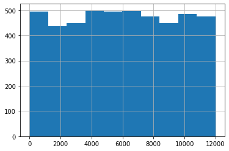

```python
df['Unnamed: 0'].hist()
```

```python
del df['Unnamed: 0']
```

```python
df.head(3).T
```

|  | 0 | 1 | 2 |
| --- | --- | --- | --- |
| custid | 2791858 | 534047 | 2849787 |
| trade_no | 20180507115231274000000023057383 | 20180507121002192000000023073000 | 20180507125159718000000023114911 |
| bank_card_no | 卡号1 | 卡号1 | 卡号1 |
| low_volume_percent | 0.01 | 0.02 | 0.04 |
| middle_volume_percent | 0.99 | 0.94 | 0.96 |
| take_amount_in_later_12_month_highest | 0 | 2000 | 0 |
| trans_amount_increase_rate_lately | 0.9 | 1.28 | 1 |
| trans_activity_month | 0.55 | 1 | 1 |
| trans_activity_day | 0.313 | 0.458 | 0.114 |
| transd_mcc | 17 | 19 | 13 |
| trans_days_interval_filter | 27 | 30 | 68 |
| trans_days_interval | 26 | 14 | 22 |
| regional_mobility | 3 | 4 | 1 |
| student_feature | NaN | 1 | NaN |
| repayment_capability | 19890 | 16970 | 9710 |
| is_high_user | 0 | 0 | 0 |
| number_of_trans_from_2011 | 30 | 23 | 9 |
| first_transaction_time | 2.01308e+07 | 2.01604e+07 | 2.01706e+07 |
| historical_trans_amount | 149050 | 302910 | 11520 |
| historical_trans_day | 151 | 224 | 31 |
| rank_trad_1_month | 0.4 | 0.35 | 1 |
| trans_amount_3_month | 34030 | 10590 | 5710 |
| avg_consume_less_12_valid_month | 7 | 5 | 5 |
| abs | 3920 | 6950 | 840 |
| top_trans_count_last_1_month | 0.15 | 0.05 | 0.65 |
| avg_price_last_12_month | 1020 | 1210 | 570 |
| avg_price_top_last_12_valid_month | 0.55 | 0.5 | 0.65 |
| reg_preference_for_trad | 一线城市 | 一线城市 | 一线城市 |
| trans_top_time_last_1_month | 4 | 13 | 0 |
| trans_top_time_last_6_month | 19 | 30 | 68 |

[output cut: 59 more lines]

## 目标 status

```python
df.status.fillna('null').value_counts()
```

```
0    3561
1    1193
Name: status, dtype: int64
```

## 划分数据集

```python
# conda install sklearn
from sklearn.model_selection import train_test_split
```

```python
train_set, test_set = train_test_split(df, test_size = 0.3, random_state=2018)
```

```python
train_set.shape
```

```
(3327, 89)
```

```python
test_set.shape
```

```
(1427, 89)
```

```python
df.shape
```

```
(4754, 89)
```

## 数据类型

```python
# 数据类型数量
train_set.dtypes.value_counts()
```

```
float64    70
int64      12
object      7
dtype: int64
```

### object

```python
df_types = train_set.dtypes
cond = df_types == 'object'
df_types[cond].index
```

```
Index(['trade_no', 'bank_card_no', 'reg_preference_for_trad', 'source',
       'id_name', 'latest_query_time', 'loans_latest_time'],
      dtype='object')
```

```python
test_set[df_types[cond].index].head(3).T
```

|  | 2248 | 3959 | 2251 |
| --- | --- | --- | --- |
| trade_no | 20180507115658623000000388217488 | 20180507115833078000000388221695 | 20180504175527473000000021273393 |
| bank_card_no | 卡号1 | 卡号1 | 卡号1 |
| reg_preference_for_trad | 一线城市 | 一线城市 | 一线城市 |
| source | xs | xs | xs |
| id_name | 郭二燊 | 明磊 | 王维策 |
| latest_query_time | 2018-04-13 | 2018-04-14 | 2018-04-24 |
| loans_latest_time | 2018-05-01 | 2018-03-26 | 2018-04-15 |

### int64

```python
df_types = train_set.dtypes
cond = df_types == 'int64'
df_types[cond].index
```

```
Index(['custid', 'take_amount_in_later_12_month_highest',
       'repayment_capability', 'is_high_user', 'historical_trans_amount',
       'trans_amount_3_month', 'abs', 'avg_price_last_12_month',
       'max_cumulative_consume_later_1_month',
       'pawns_auctions_trusts_consume_last_1_month',
       'pawns_auctions_trusts_consume_last_6_month', 'status'],
      dtype='object')
```

```python
test_set[df_types[cond].index].head(3).T
```

|  | 2248 | 3959 | 2251 |
| --- | --- | --- | --- |
| custid | 2179871 | 2689718 | 47426 |
| take_amount_in_later_12_month_highest | 0 | 1500 | 3000 |
| repayment_capability | 4650 | 2540 | 28160 |
| is_high_user | 0 | 0 | 0 |
| historical_trans_amount | 168590 | 227470 | 959780 |
| trans_amount_3_month | 23060 | 43810 | 114140 |
| abs | 19020 | 10040 | 6110 |
| avg_price_last_12_month | 1580 | 1240 | 1660 |
| max_cumulative_consume_later_1_month | 0 | 1970 | 2290 |
| pawns_auctions_trusts_consume_last_1_month | 0 | 0 | 1150 |
| pawns_auctions_trusts_consume_last_6_month | 21920 | 28890 | 90330 |
| status | 0 | 0 | 1 |

### float64

```python
df_types = train_set.dtypes
cond = df_types == 'float64'
df_types[cond].index
```

```
Index(['low_volume_percent', 'middle_volume_percent',
       'trans_amount_increase_rate_lately', 'trans_activity_month',
       'trans_activity_day', 'transd_mcc', 'trans_days_interval_filter',
       'trans_days_interval', 'regional_mobility', 'student_feature',
       'number_of_trans_from_2011', 'first_transaction_time',
       'historical_trans_day', 'rank_trad_1_month',
       'avg_consume_less_12_valid_month', 'top_trans_count_last_1_month',
       'avg_price_top_last_12_valid_month', 'trans_top_time_last_1_month',
       'trans_top_time_last_6_month', 'consume_top_time_last_1_month',
       'consume_top_time_last_6_month', 'cross_consume_count_last_1_month',
       'trans_fail_top_count_enum_last_1_month',
       'trans_fail_top_count_enum_last_6_month',
       'trans_fail_top_count_enum_last_12_month',
       'consume_mini_time_last_1_month', 'max_consume_count_later_6_month',
       'railway_consume_count_last_12_month',
       'jewelry_consume_count_last_6_month', 'first_transaction_day',
       'trans_day_last_12_month', 'apply_score', 'apply_credibility',
       'query_org_count', 'query_finance_count', 'query_cash_count',
       'query_sum_count', 'latest_one_month_apply', 'latest_three_month_apply',
       'latest_six_month_apply', 'loans_score', 'loans_credibility_behavior',
       'loans_count', 'loans_settle_count', 'loans_overdue_count',
       'loans_org_count_behavior', 'consfin_org_count_behavior',
       'loans_cash_count', 'latest_one_month_loan', 'latest_three_month_loan',
       'latest_six_month_loan', 'history_suc_fee', 'history_fail_fee',
       'latest_one_month_suc', 'latest_one_month_fail', 'loans_long_time',
       'loans_credit_limit', 'loans_credibility_limit',
       'loans_org_count_current', 'loans_product_count', 'loans_max_limit',
       'loans_avg_limit', 'consfin_credit_limit', 'consfin_credibility',
       'consfin_org_count_current', 'consfin_product_count',
       'consfin_max_limit', 'consfin_avg_limit', 'latest_query_day',
       'loans_latest_day'],
      dtype='object')
```

```python
test_set[df_types[cond].index].head(3).T
```

|  | 2248 | 3959 | 2251 |
| --- | --- | --- | --- |
| low_volume_percent | 0.000000e+00 | 0.01 | 0.000000e+00 |
| middle_volume_percent | 1.000000e+00 | 0.94 | 8.000000e-01 |
| trans_amount_increase_rate_lately | 3.500000e-01 | 0.51 | 1.100000e+00 |
| trans_activity_month | 8.300000e-01 | 0.61 | 9.400000e-01 |
| trans_activity_day | 3.970000e-01 | 0.50 | 7.270000e-01 |
| transd_mcc | 1.800000e+01 | 21.00 | 2.500000e+01 |
| trans_days_interval_filter | 3.300000e+01 | 31.00 | 7.000000e+00 |
| trans_days_interval | 1.100000e+01 | 17.00 | 6.000000e+00 |
| regional_mobility | 3.000000e+00 | 3.00 | 3.000000e+00 |
| student_feature | NaN | 1.00 | 1.000000e+00 |
| number_of_trans_from_2011 | 2.500000e+01 | 19.00 | 3.100000e+01 |
| first_transaction_time | 2.015091e+07 | 20150828.00 | 2.014090e+07 |
| historical_trans_day | 2.290000e+02 | 187.00 | 4.670000e+02 |
| rank_trad_1_month | 1.000000e+00 | 0.40 | 2.500000e-01 |
| avg_consume_less_12_valid_month | 7.000000e+00 | 8.00 | 7.000000e+00 |
| top_trans_count_last_1_month | 1.000000e+00 | 0.40 | 5.000000e-02 |
| avg_price_top_last_12_valid_month | 4.500000e-01 | 0.50 | 4.000000e-01 |
| trans_top_time_last_1_month | 0.000000e+00 | 19.00 | 6.000000e+00 |
| trans_top_time_last_6_month | 1.200000e+01 | 19.00 | 7.000000e+00 |
| consume_top_time_last_1_month | 0.000000e+00 | 19.00 | 6.000000e+00 |
| consume_top_time_last_6_month | 1.200000e+01 | 19.00 | 7.000000e+00 |
| cross_consume_count_last_1_month | 0.000000e+00 | 0.00 | 0.000000e+00 |
| trans_fail_top_count_enum_last_1_month | 0.000000e+00 | 1.00 | 5.000000e+00 |
| trans_fail_top_count_enum_last_6_month | 1.000000e+00 | 2.00 | 8.000000e+00 |
| trans_fail_top_count_enum_last_12_month | 2.000000e+00 | 2.00 | 8.000000e+00 |
| consume_mini_time_last_1_month | 0.000000e+00 | 0.00 | 1.475926e+06 |
| max_consume_count_later_6_month | 3.000000e+00 | 6.00 | 6.000000e+00 |
| railway_consume_count_last_12_month | 0.000000e+00 | 0.00 | 0.000000e+00 |
| jewelry_consume_count_last_6_month | 0.000000e+00 | 0.00 | 0.000000e+00 |
| first_transaction_day | 9.880000e+02 | 997.00 | 1.357000e+03 |
| trans_day_last_12_month | 8.200000e+01 | 83.00 | 8.500000e+01 |
| apply_score | 5.430000e+02 | 656.00 | 5.290000e+02 |
| apply_credibility | 8.100000e+01 | 78.00 | 7.900000e+01 |
| query_org_count | 1.000000e+01 | 17.00 | 1.200000e+01 |
| query_finance_count | 7.000000e+00 | 5.00 | 6.000000e+00 |
| query_cash_count | 2.000000e+00 | 5.00 | 4.000000e+00 |
| query_sum_count | 1.300000e+01 | 22.00 | 1.600000e+01 |
| latest_one_month_apply | 2.000000e+00 | 6.00 | 5.000000e+00 |
| latest_three_month_apply | 1.000000e+01 | 11.00 | 9.000000e+00 |
| latest_six_month_apply | 1.300000e+01 | 12.00 | 1.300000e+01 |
| loans_score | 5.120000e+02 | 635.00 | 4.760000e+02 |
| loans_credibility_behavior | 7.600000e+01 | 76.00 | 7.600000e+01 |
| loans_count | 3.200000e+01 | 68.00 | 8.900000e+01 |
| loans_settle_count | 3.200000e+01 | 67.00 | 7.000000e+01 |
| loans_overdue_count | 4.000000e+00 | 0.00 | 5.000000e+00 |
| loans_org_count_behavior | 8.000000e+00 | 26.00 | 2.600000e+01 |
| consfin_org_count_behavior | 5.000000e+00 | 10.00 | 1.000000e+01 |
| loans_cash_count | 3.000000e+00 | 16.00 | 1.600000e+01 |
| latest_one_month_loan | 1.000000e+00 | 0.00 | 1.000000e+00 |
| latest_three_month_loan | 1.000000e+00 | 3.00 | 2.000000e+00 |
| latest_six_month_loan | 8.000000e+00 | 17.00 | 3.400000e+01 |
| history_suc_fee | 4.200000e+01 | 81.00 | 9.600000e+01 |
| history_fail_fee | 2.000000e+00 | 9.00 | 4.800000e+01 |
| latest_one_month_suc | 2.000000e+00 | 2.00 | 0.000000e+00 |
| latest_one_month_fail | 0.000000e+00 | 0.00 | 1.000000e+00 |
| loans_long_time | 3.590000e+02 | 352.00 | 3.560000e+02 |
| loans_credit_limit | 2.600000e+03 | 2100.00 | 2.500000e+03 |
| loans_credibility_limit | 7.300000e+01 | 75.00 | 7.600000e+01 |
| loans_org_count_current | 3.000000e+00 | 16.00 | 1.600000e+01 |
| loans_product_count | 3.000000e+00 | 17.00 | 1.700000e+01 |
| loans_max_limit | 3.000000e+03 | 5400.00 | 6.000000e+03 |
| loans_avg_limit | 1.900000e+03 | 1887.00 | 2.387000e+03 |
| consfin_credit_limit | 9.100000e+03 | 6700.00 | 6.800000e+03 |
| consfin_credibility | 8.000000e+01 | 78.00 | 7.800000e+01 |
| consfin_org_count_current | 5.000000e+00 | 10.00 | 1.000000e+01 |
| consfin_product_count | 5.000000e+00 | 11.00 | 1.200000e+01 |
| consfin_max_limit | 1.800000e+04 | 13200.00 | 2.280000e+04 |
| consfin_avg_limit | 7.300000e+03 | 6640.00 | 7.480000e+03 |
| latest_query_day | 2.400000e+01 | 23.00 | 1.000000e+01 |
| loans_latest_day | 6.000000e+00 | 42.00 | 1.900000e+01 |

```python
train_set.info()
```

```
<class 'pandas.core.frame.DataFrame'>
Int64Index: 3327 entries, 110 to 1274
Data columns (total 89 columns):
custid                                        3327 non-null int64
trade_no                                      3327 non-null object
bank_card_no                                  3327 non-null object
low_volume_percent                            3325 non-null float64
middle_volume_percent                         3325 non-null float64
take_amount_in_later_12_month_highest         3327 non-null int64
trans_amount_increase_rate_lately             3325 non-null float64
trans_activity_month                          3325 non-null float64
trans_activity_day                            3325 non-null float64
transd_mcc                                    3325 non-null float64
trans_days_interval_filter                    3321 non-null float64
trans_days_interval                           3325 non-null float64
regional_mobility                             3325 non-null float64
student_feature                               1208 non-null float64
repayment_capability                          3327 non-null int64
is_high_user                                  3327 non-null int64
number_of_trans_from_2011                     3325 non-null float64
first_transaction_time                        3325 non-null float64
historical_trans_amount                       3327 non-null int64
historical_trans_day                          3325 non-null float64
rank_trad_1_month                             3325 non-null float64
trans_amount_3_month                          3327 non-null int64
avg_consume_less_12_valid_month               3325 non-null float64
abs                                           3327 non-null int64
top_trans_count_last_1_month                  3325 non-null float64
avg_price_last_12_month                       3327 non-null int64
avg_price_top_last_12_valid_month             3249 non-null float64
reg_preference_for_trad                       3325 non-null object
trans_top_time_last_1_month                   3321 non-null float64
trans_top_time_last_6_month                   3321 non-null float64
consume_top_time_last_1_month                 3321 non-null float64
consume_top_time_last_6_month                 3321 non-null float64
cross_consume_count_last_1_month              3037 non-null float64
trans_fail_top_count_enum_last_1_month        3314 non-null float64
trans_fail_top_count_enum_last_6_month        3314 non-null float64
trans_fail_top_count_enum_last_12_month       3314 non-null float64
consume_mini_time_last_1_month                3312 non-null float64
```

[output cut: 39 more lines]

```
loans_credibility_limit                       3112 non-null float64
loans_org_count_current                       3112 non-null float64
loans_product_count                           3112 non-null float64
loans_max_limit                               3112 non-null float64
loans_avg_limit                               3112 non-null float64
consfin_credit_limit                          3112 non-null float64
consfin_credibility                           3112 non-null float64
consfin_org_count_current                     3112 non-null float64
consfin_product_count                         3112 non-null float64
consfin_max_limit                             3112 non-null float64
consfin_avg_limit                             3112 non-null float64
latest_query_day                              3107 non-null float64
loans_latest_day                              3112 non-null float64
dtypes: float64(70), int64(12), object(7)
memory usage: 2.3+ MB
```

# 特征工程

任务1：对数据进行探索和分析。时间：2天

- 数据类型的分析
- 无关特征删除
- 数据类型转换
- 缺失值处理
- ……以及你能想到和借鉴的数据分析处理

```python
train_set = train_set.copy()
```

```python
status = train_set['status']
del train_set['status']
train_set['status'] = status
```

```python
train_set.shape
```

```
(3327, 89)
```

```python
for i in range(0, train_set.shape[1],9):
    print(i, i+9)
```

```
0 9
9 18
18 27
27 36
36 45
45 54
54 63
63 72
72 81
81 90
```

```python
# for i in range(0, train_set.shape[1],9):
#     # print(i, i+9)
#     print( train_set.columns[i:i+9])
#     train_set.iloc[:, i:i+9].hist(bins=50, figsize = (20,15))
#     plt.show()
```

```python
train_set.isnull().sum()
```

```
custid                                           0
trade_no                                         0
bank_card_no                                     0
low_volume_percent                               2
middle_volume_percent                            2
take_amount_in_later_12_month_highest            0
trans_amount_increase_rate_lately                2
trans_activity_month                             2
trans_activity_day                               2
transd_mcc                                       2
trans_days_interval_filter                       6
trans_days_interval                              2
regional_mobility                                2
student_feature                               2119
repayment_capability                             0
is_high_user                                     0
number_of_trans_from_2011                        2
first_transaction_time                           2
historical_trans_amount                          0
historical_trans_day                             2
rank_trad_1_month                                2
trans_amount_3_month                             0
avg_consume_less_12_valid_month                  2
abs                                              0
top_trans_count_last_1_month                     2
avg_price_last_12_month                          0
avg_price_top_last_12_valid_month               78
reg_preference_for_trad                          2
trans_top_time_last_1_month                      6
trans_top_time_last_6_month                      6
consume_top_time_last_1_month                    6
consume_top_time_last_6_month                    6
cross_consume_count_last_1_month               290
trans_fail_top_count_enum_last_1_month          13
trans_fail_top_count_enum_last_6_month          13
trans_fail_top_count_enum_last_12_month         13
consume_mini_time_last_1_month                  15
max_cumulative_consume_later_1_month             0
max_consume_count_later_6_month                  6
railway_consume_count_last_12_month              8
```

[output cut: 35 more lines]

```
loans_credibility_limit                        215
loans_org_count_current                        215
loans_product_count                            215
loans_max_limit                                215
loans_avg_limit                                215
consfin_credit_limit                           215
consfin_credibility                            215
consfin_org_count_current                      215
consfin_product_count                          215
consfin_max_limit                              215
consfin_avg_limit                              215
latest_query_day                               220
loans_latest_day                               215
status                                           0
dtype: int64
```

## part1 0:9 列

```python
i,j = 0,9
train_set.columns[i:j]
```

```
Index(['custid', 'trade_no', 'bank_card_no', 'low_volume_percent',
       'middle_volume_percent', 'take_amount_in_later_12_month_highest',
       'trans_amount_increase_rate_lately', 'trans_activity_month',
       'trans_activity_day'],
      dtype='object')
```

#### fig

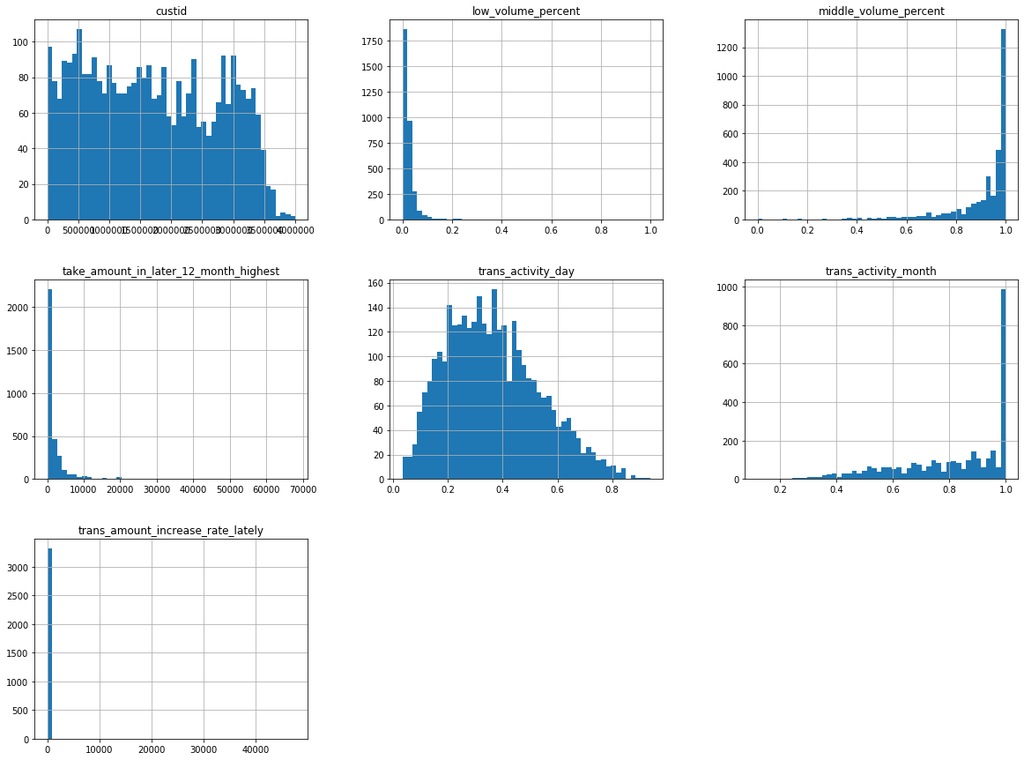

```python
obj = train_set[train_set.columns[i:j]]
obj.hist(bins=50, figsize = (20,15))
plt.show()
```

```python
obj.head(3).T
```

|  | 110 | 3394 | 3052 |
| --- | --- | --- | --- |
| custid | 3302657 | 2733732 | 2851871 |
| trade_no | 20180504182022079000000381847944 | 20180507115234629000000023058189 | 20180507121124018000000388268874 |
| bank_card_no | 卡号1 | 卡号1 | 卡号1 |
| low_volume_percent | 0.01 | 0.03 | 0.02 |
| middle_volume_percent | 0.99 | 0.97 | 0.86 |
| take_amount_in_later_12_month_highest | 4000 | 500 | 0 |
| trans_amount_increase_rate_lately | 0.96 | 0.87 | 1.98 |
| trans_activity_month | 1 | 1 | 0.7 |
| trans_activity_day | 0.405 | 0.205 | 0.205 |

#### null

```python
obj.isnull().sum()
```

```
custid                                   0
trade_no                                 0
bank_card_no                             0
low_volume_percent                       2
middle_volume_percent                    2
take_amount_in_later_12_month_highest    0
trans_amount_increase_rate_lately        2
trans_activity_month                     2
trans_activity_day                       2
dtype: int64
```

### custid

```python
# 00 custid 顾客ID号 没有重复
train_set.custid.duplicated().sum()
```

```
0
```

### trade_no

```python
# 01 trade_no 交易号 没有重复, 可以删除？
train_set.trade_no.duplicated().sum()
```

```
0
```

#### 疑问

交易号是否会与时间有关联

### bank_card_no

```python
# 02 卡号均为1，可以删除
train_set.bank_card_no.value_counts()
```

```
卡号1    3327
Name: bank_card_no, dtype: int64
```

### [2] volume_percent

```python
# 03,04 刷卡额度所占比例, 有2个空值
[i for i in test_set.columns if 'volume_percent' in i]
```

```
['low_volume_percent', 'middle_volume_percent']
```

```python
# low_volume_percent + middle_volume_percent
# 值在 0~1之间， 应该还有一个值 high_volume_percent
volume_percent_sum = train_set.low_volume_percent + train_set.middle_volume_percent
pd.Series(volume_percent_sum.value_counts().index).describe()
```

```
count    110.000000
mean       0.631909
std        0.262820
min        0.000000
25%        0.432500
50%        0.675000
75%        0.860000
max        1.010000
dtype: float64
```

```python
pd.concat([volume_percent_sum.value_counts().iloc[:5],
           volume_percent_sum.value_counts().iloc[-5:],
          ])
```

```
1.00    1895
0.96      75
0.98      74
0.97      74
0.92      59
0.38       1
0.33       1
0.29       1
0.19       1
0.73       1
dtype: int64
```

```python
# 需要判断这2行空值是否可以删除，过去12个月没有消费
cond = train_set.low_volume_percent.isnull()
obj[cond].T
```

|  | 2703 | 3740 |
| --- | --- | --- |
| custid | 2346029 | 2123079 |
| trade_no | 20180507122903344000000023090358 | 20180507123543218000000023096586 |
| bank_card_no | 卡号1 | 卡号1 |
| low_volume_percent | NaN | NaN |
| middle_volume_percent | NaN | NaN |
| take_amount_in_later_12_month_highest | 0 | 0 |
| trans_amount_increase_rate_lately | NaN | NaN |
| trans_activity_month | NaN | NaN |
| trans_activity_day | NaN | NaN |

```python
train_set.loc[cond, 'status']
```

```
2703    0
3740    0
Name: status, dtype: int64
```

```python
train_set[cond].T
```

|  | 2703 | 3740 |
| --- | --- | --- |
| custid | 2346029 | 2123079 |
| trade_no | 20180507122903344000000023090358 | 20180507123543218000000023096586 |
| bank_card_no | 卡号1 | 卡号1 |
| low_volume_percent | NaN | NaN |
| middle_volume_percent | NaN | NaN |
| take_amount_in_later_12_month_highest | 0 | 0 |
| trans_amount_increase_rate_lately | NaN | NaN |
| trans_activity_month | NaN | NaN |
| trans_activity_day | NaN | NaN |
| transd_mcc | NaN | NaN |
| trans_days_interval_filter | NaN | NaN |
| trans_days_interval | NaN | NaN |
| regional_mobility | NaN | NaN |
| student_feature | NaN | NaN |
| repayment_capability | 0 | 0 |
| is_high_user | 0 | 0 |
| number_of_trans_from_2011 | NaN | NaN |
| first_transaction_time | NaN | NaN |
| historical_trans_amount | 0 | 0 |
| historical_trans_day | NaN | NaN |
| rank_trad_1_month | NaN | NaN |
| trans_amount_3_month | 0 | 0 |
| avg_consume_less_12_valid_month | NaN | NaN |
| abs | 0 | 0 |
| top_trans_count_last_1_month | NaN | NaN |
| avg_price_last_12_month | 0 | 0 |
| avg_price_top_last_12_valid_month | NaN | NaN |
| reg_preference_for_trad | NaN | NaN |
| trans_top_time_last_1_month | NaN | NaN |
| trans_top_time_last_6_month | NaN | NaN |

[output cut: 59 more lines]

```python
# 去除这2行
train_set = train_set[~cond].copy()
```

```python
train_set.isnull().sum()
```

```
custid                                           0
trade_no                                         0
bank_card_no                                     0
low_volume_percent                               0
middle_volume_percent                            0
take_amount_in_later_12_month_highest            0
trans_amount_increase_rate_lately                0
trans_activity_month                             0
trans_activity_day                               0
transd_mcc                                       0
trans_days_interval_filter                       4
trans_days_interval                              0
regional_mobility                                0
student_feature                               2117
repayment_capability                             0
is_high_user                                     0
number_of_trans_from_2011                        0
first_transaction_time                           0
historical_trans_amount                          0
historical_trans_day                             0
rank_trad_1_month                                0
trans_amount_3_month                             0
avg_consume_less_12_valid_month                  0
abs                                              0
top_trans_count_last_1_month                     0
avg_price_last_12_month                          0
avg_price_top_last_12_valid_month               76
reg_preference_for_trad                          0
trans_top_time_last_1_month                      4
trans_top_time_last_6_month                      4
consume_top_time_last_1_month                    4
consume_top_time_last_6_month                    4
cross_consume_count_last_1_month               288
trans_fail_top_count_enum_last_1_month          11
trans_fail_top_count_enum_last_6_month          11
trans_fail_top_count_enum_last_12_month         11
consume_mini_time_last_1_month                  13
max_cumulative_consume_later_1_month             0
max_consume_count_later_6_month                  4
railway_consume_count_last_12_month              6
```

[output cut: 35 more lines]

```
loans_credibility_limit                        215
loans_org_count_current                        215
loans_product_count                            215
loans_max_limit                                215
loans_avg_limit                                215
consfin_credit_limit                           215
consfin_credibility                            215
consfin_org_count_current                      215
consfin_product_count                          215
consfin_max_limit                              215
consfin_avg_limit                              215
latest_query_day                               220
loans_latest_day                               215
status                                           0
dtype: int64
```

### take_amount_in_later_12_month_highest

过去12个月最高贷款额度

```python
col = 'take_amount_in_later_12_month_highest'
```

```python
train_set[col].isnull().sum()
```

```
0
```

```python
train_set[col].describe()
```

```
count     3325.000000
mean      1947.906767
std       4114.794418
min          0.000000
25%          0.000000
50%        500.000000
75%       2000.000000
max      68000.000000
Name: take_amount_in_later_12_month_highest, dtype: float64
```

```python
train_set.groupby('status')[col].describe().T
```

| status | 0 | 1 |
| --- | --- | --- |
| count | 2491.000000 | 834.000000 |
| mean | 1964.223204 | 1899.172662 |
| std | 4285.471026 | 3558.509394 |
| min | 0.000000 | 0.000000 |
| 25% | 0.000000 | 0.000000 |
| 50% | 500.000000 | 550.000000 |
| 75% | 2000.000000 | 2000.000000 |
| max | 68000.000000 | 27000.000000 |

### trans_amount_increase_rate_lately

```python
col = 'trans_amount_increase_rate_lately'
```

```python
train_set[col].isnull().sum()
```

```
0
```

```python
train_set[col].describe()
```

```
count     3325.000000
mean        19.065489
std        829.746170
min          0.000000
25%          0.600000
50%          0.970000
75%          1.620000
max      47596.740000
Name: trans_amount_increase_rate_lately, dtype: float64
```

```python
train_set.groupby('status')[col].describe().T
```

| status | 0 | 1 |
| --- | --- | --- |
| count | 2491.000000 | 834.000000 |
| mean | 24.474641 | 2.909376 |
| std | 958.523634 | 24.040586 |
| min | 0.000000 | 0.000000 |
| 25% | 0.590000 | 0.662500 |
| 50% | 0.960000 | 0.990000 |
| 75% | 1.660000 | 1.460000 |
| max | 47596.740000 | 672.670000 |

```python
obj.columns
```

```
Index(['custid', 'trade_no', 'bank_card_no', 'low_volume_percent',
       'middle_volume_percent', 'take_amount_in_later_12_month_highest',
       'trans_amount_increase_rate_lately', 'trans_activity_month',
       'trans_activity_day'],
      dtype='object')
```

```python
train_set[col].describe()
```

```
count     3325.000000
mean        19.065489
std        829.746170
min          0.000000
25%          0.600000
50%          0.970000
75%          1.620000
max      47596.740000
Name: trans_amount_increase_rate_lately, dtype: float64
```

```python
train_set.groupby('status')['trans_amount_increase_rate_lately'].describe().T
```

| status | 0 | 1 |
| --- | --- | --- |
| count | 2491.000000 | 834.000000 |
| mean | 24.474641 | 2.909376 |
| std | 958.523634 | 24.040586 |
| min | 0.000000 | 0.000000 |
| 25% | 0.590000 | 0.662500 |
| 50% | 0.960000 | 0.990000 |
| 75% | 1.660000 | 1.460000 |
| max | 47596.740000 | 672.670000 |

```python
cond = obj.trans_amount_increase_rate_lately > 100
obj[cond].shape
```

```
(10, 9)
```

```python
obj.loc[cond, 'trans_amount_increase_rate_lately'].describe()
```

```
count       10.000000
mean      5573.824000
std      14828.248374
min        152.360000
25%        195.062500
50%        490.485000
75%        937.410000
max      47596.740000
Name: trans_amount_increase_rate_lately, dtype: float64
```

### [2] trans_activity_month & trans_activity_day

每月、每日交易活跃度

```python
obj.columns
```

```
Index(['custid', 'trade_no', 'bank_card_no', 'low_volume_percent',
       'middle_volume_percent', 'take_amount_in_later_12_month_highest',
       'trans_amount_increase_rate_lately', 'trans_activity_month',
       'trans_activity_day'],
      dtype='object')
```

```python
obj.trans_activity_month.describe()
```

```
count    3325.000000
mean        0.806848
std         0.196462
min         0.120000
25%         0.670000
50%         0.860000
75%         1.000000
max         1.000000
Name: trans_activity_month, dtype: float64
```

```python
obj.trans_activity_day.describe()
```

```
count    3325.000000
mean        0.364448
std         0.170165
min         0.033000
25%         0.230000
50%         0.350000
75%         0.477000
max         0.941000
Name: trans_activity_day, dtype: float64
```

```python
train_set.groupby('status')['trans_activity_month'].describe().T
```

| status | 0 | 1 |
| --- | --- | --- |
| count | 2491.000000 | 834.000000 |
| mean | 0.806616 | 0.807542 |
| std | 0.197212 | 0.194317 |
| min | 0.120000 | 0.150000 |
| 25% | 0.670000 | 0.670000 |
| 50% | 0.860000 | 0.870000 |
| 75% | 1.000000 | 1.000000 |
| max | 1.000000 | 1.000000 |

```python
train_set.groupby('status')['trans_activity_day'].describe().T
```

| status | 0 | 1 |
| --- | --- | --- |
| count | 2491.000000 | 834.000000 |
| mean | 0.366522 | 0.358252 |
| std | 0.169738 | 0.171390 |
| min | 0.033000 | 0.033000 |
| 25% | 0.236000 | 0.219000 |
| 50% | 0.350000 | 0.344000 |
| 75% | 0.477000 | 0.475000 |
| max | 0.941000 | 0.833000 |

日活跃度高的是否意味着更不容易逾期？

### 填充空值

```python
obj.columns
```

```
Index(['custid', 'trade_no', 'bank_card_no', 'low_volume_percent',
       'middle_volume_percent', 'take_amount_in_later_12_month_highest',
       'trans_amount_increase_rate_lately', 'trans_activity_month',
       'trans_activity_day'],
      dtype='object')
```

```python
train_set = train_set.copy()
```

```python
# for col in [ 'low_volume_percent', 'middle_volume_percent',
#        'trans_amount_increase_rate_lately', 'trans_activity_month',
#        'trans_activity_day']:
#     # break
#     train_set[col] = train_set[col].fillna(0)
```

## part2 9:18 列

```python
i,j = 9,18
train_set.columns[i:j]
```

```
Index(['transd_mcc', 'trans_days_interval_filter', 'trans_days_interval',
       'regional_mobility', 'student_feature', 'repayment_capability',
       'is_high_user', 'number_of_trans_from_2011', 'first_transaction_time'],
      dtype='object')
```

#### fig

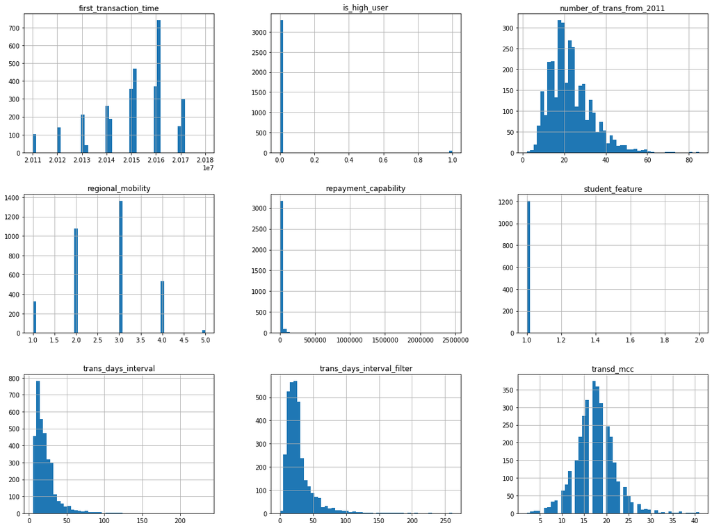

```python
obj = train_set[train_set.columns[i:j]]
obj.hist(bins=50, figsize = (20,15))
plt.show()
```

```python
obj.head(3).T
```

|  | 110 | 3394 | 3052 |
| --- | --- | --- | --- |
| transd_mcc | 16.0 | 18.0 | 18.0 |
| trans_days_interval_filter | 29.0 | 27.0 | 53.0 |
| trans_days_interval | 28.0 | 27.0 | 33.0 |
| regional_mobility | 1.0 | 3.0 | 2.0 |
| student_feature | 1.0 | NaN | NaN |
| repayment_capability | 17570.0 | 15310.0 | 12240.0 |
| is_high_user | 0.0 | 0.0 | 0.0 |
| number_of_trans_from_2011 | 13.0 | 12.0 | 28.0 |
| first_transaction_time | 20170217.0 | 20170331.0 | 20141110.0 |

#### null

```python
obj.isnull().sum()
```

```
transd_mcc                       0
trans_days_interval_filter       4
trans_days_interval              0
regional_mobility                0
student_feature               2117
repayment_capability             0
is_high_user                     0
number_of_trans_from_2011        0
first_transaction_time           0
dtype: int64
```

### transd_mcc

??

```python
col = 'transd_mcc'
train_set[col].isnull().sum()
```

```
0
```

```python
train_set[col].describe()
```

```
count    3325.000000
mean       17.446316
std         4.486967
min         2.000000
25%        15.000000
50%        17.000000
75%        20.000000
max        41.000000
Name: transd_mcc, dtype: float64
```

```python
# 取中位数
# train_set['transd_mcc'] = train_set['transd_mcc'].fillna(train_set['transd_mcc'].median())
```

### trans_days_interval_filter

交易日间隔？？

```python
col = 'trans_days_interval_filter'
train_set[col].isnull().sum()
```

```
4
```

```python
train_set[col].describe()
```

```
count    3321.000000
mean       28.980729
std        22.315568
min         0.000000
25%        16.000000
50%        24.000000
75%        33.000000
max       261.000000
Name: trans_days_interval_filter, dtype: float64
```

```python
train_set['trans_days_interval_filter'] = train_set['trans_days_interval_filter'].fillna(9999)
```

### trans_days_interval

```python
obj.columns
```

```
Index(['transd_mcc', 'trans_days_interval_filter', 'trans_days_interval',
       'regional_mobility', 'student_feature', 'repayment_capability',
       'is_high_user', 'number_of_trans_from_2011', 'first_transaction_time'],
      dtype='object')
```

```python
col = 'trans_days_interval'
train_set[col].isnull().sum()
```

```
0
```

```python
train_set[col].describe()
```

```
count    3325.000000
mean       21.678496
std        16.430096
min         5.000000
25%        12.000000
50%        17.000000
75%        26.000000
max       234.000000
Name: trans_days_interval, dtype: float64
```

```python
# train_set['trans_days_interval'] = train_set['trans_days_interval'].fillna(9999)
```

### 【分类】regional_mobility

区域流动性

```python
obj.columns
```

```
Index(['transd_mcc', 'trans_days_interval_filter', 'trans_days_interval',
       'regional_mobility', 'student_feature', 'repayment_capability',
       'is_high_user', 'number_of_trans_from_2011', 'first_transaction_time'],
      dtype='object')
```

```python
col = 'regional_mobility'
train_set[col].isnull().sum()
```

```
0
```

```python
train_set[col].describe()
```

```
count    3325.000000
mean        2.656842
std         0.887718
min         1.000000
25%         2.000000
50%         3.000000
75%         3.000000
max         5.000000
Name: regional_mobility, dtype: float64
```

```python
train_set[col].value_counts()
```

```
3.0    1364
2.0    1076
4.0     535
1.0     325
5.0      25
Name: regional_mobility, dtype: int64
```

```python
train_set[col].mode()
```

```
0    3.0
dtype: float64
```

```python
# train_set['regional_mobility'] = train_set['regional_mobility'].fillna(3)
```

### 【分类】student_feature

学生属性

```python
obj.columns
```

```
Index(['transd_mcc', 'trans_days_interval_filter', 'trans_days_interval',
       'regional_mobility', 'student_feature', 'repayment_capability',
       'is_high_user', 'number_of_trans_from_2011', 'first_transaction_time'],
      dtype='object')
```

```python
col = 'student_feature'
train_set[col].isnull().sum()
```

```
2117
```

```python
train_set[col].describe()
```

```
count    1208.000000
mean        1.000828
std         0.028772
min         1.000000
25%         1.000000
50%         1.000000
75%         1.000000
max         2.000000
Name: student_feature, dtype: float64
```

```python
train_set[col].value_counts()
```

```
1.0    1207
2.0       1
Name: student_feature, dtype: int64
```

```python
train_set['student_feature'] = train_set['student_feature'].fillna(0)
```

### repayment_capability

支付能力

```python
obj.columns
```

```
Index(['transd_mcc', 'trans_days_interval_filter', 'trans_days_interval',
       'regional_mobility', 'student_feature', 'repayment_capability',
       'is_high_user', 'number_of_trans_from_2011', 'first_transaction_time'],
      dtype='object')
```

```python
col = 'repayment_capability'
train_set[col].isnull().sum()
```

```
0
```

```python
train_set[col].describe()
```

```
count    3.325000e+03
mean     1.915265e+04
std      5.856023e+04
min      0.000000e+00
25%      8.680000e+03
50%      1.224000e+04
75%      1.769000e+04
max      2.459390e+06
Name: repayment_capability, dtype: float64
```

```python
train_set['student_feature'] = train_set['student_feature'].fillna(0)
```

```python
train_set.groupby('status')[col].describe().T
```

| status | 0 | 1 |
| --- | --- | --- |
| count | 2.491000e+03 | 834.000000 |
| mean | 1.980238e+04 | 17212.050360 |
| std | 6.596767e+04 | 25904.703444 |
| min | 0.000000e+00 | 10.000000 |
| 25% | 8.690000e+03 | 8600.000000 |
| 50% | 1.232000e+04 | 11940.000000 |
| 75% | 1.770500e+04 | 17592.500000 |
| max | 2.459390e+06 | 455500.000000 |

### 【分类】is_high_user

高价值用户？

```python
obj.columns
```

```
Index(['transd_mcc', 'trans_days_interval_filter', 'trans_days_interval',
       'regional_mobility', 'student_feature', 'repayment_capability',
       'is_high_user', 'number_of_trans_from_2011', 'first_transaction_time'],
      dtype='object')
```

```python
col = 'is_high_user'
train_set[col].isnull().sum()
```

```
0
```

```python
train_set[col].describe()
```

```
count    3325.000000
mean        0.011729
std         0.107681
min         0.000000
25%         0.000000
50%         0.000000
75%         0.000000
max         1.000000
Name: is_high_user, dtype: float64
```

```python
train_set[col].value_counts()
```

```
0    3286
1      39
Name: is_high_user, dtype: int64
```

```python
# train_set['is_high_user'] = train_set['is_high_user'].fillna(0)
```

### number_of_trans_from_2011

从2011年至今的交易数

```python
obj.columns
```

```
Index(['transd_mcc', 'trans_days_interval_filter', 'trans_days_interval',
       'regional_mobility', 'student_feature', 'repayment_capability',
       'is_high_user', 'number_of_trans_from_2011', 'first_transaction_time'],
      dtype='object')
```

```python
col = 'number_of_trans_from_2011'
train_set[col].isnull().sum()
```

```
0
```

```python
train_set[col].describe()
```

```
count    3325.000000
mean       22.958496
std        10.063042
min         2.000000
25%        16.000000
50%        21.000000
75%        29.000000
max        85.000000
Name: number_of_trans_from_2011, dtype: float64
```

```python
train_set.groupby('status')[col].describe().T
```

| status | 0 | 1 |
| --- | --- | --- |
| count | 2491.000000 | 834.000000 |
| mean | 23.250100 | 22.087530 |
| std | 10.134818 | 9.799957 |
| min | 2.000000 | 4.000000 |
| 25% | 16.000000 | 15.000000 |
| 50% | 22.000000 | 20.000000 |
| 75% | 29.000000 | 27.000000 |
| max | 85.000000 | 62.000000 |

```python
# train_set[col].value_counts()
```

```python
col
```

```
'number_of_trans_from_2011'
```

```python
# train_set['number_of_trans_from_2011'] = train_set['number_of_trans_from_2011'].fillna(0)
```

### 【日期】first_transaction_time

第一次交易时间

可构建日期，时间特征

日期范围—— 20110101 - 20180114

```python
obj.columns
```

```
Index(['transd_mcc', 'trans_days_interval_filter', 'trans_days_interval',
       'regional_mobility', 'student_feature', 'repayment_capability',
       'is_high_user', 'number_of_trans_from_2011', 'first_transaction_time'],
      dtype='object')
```

```python
col = 'first_transaction_time'
train_set[col].isnull().sum()
```

```
0
```

```python
# cond = train_set[col].isnull()
# train_set[cond].T
```

```python
train_set[col].head()
```

```
110     20170217.0
3394    20170331.0
3052    20141110.0
490     20130817.0
1       20160402.0
Name: first_transaction_time, dtype: float64
```

```python
train_set['first_transaction_time'] = train_set['first_transaction_time'].astype(int).astype(str)
```

```python
train_set['first_transaction_time'].str[:6].value_counts().head()
```

```
201609    113
201605    108
201505    107
201606    103
201607    101
Name: first_transaction_time, dtype: int64
```

```python
train_set['first_transaction_time'].max()
```

```
'20180114'
```

```python
train_set['first_transaction_time'].min()
```

```
'20110101'
```

```python
test_set['first_transaction_time'].max()
```

```
20180114.0
```

## part3 18:27 列

```python
i,j = 18,27
train_set.columns[i:j]
```

```
Index(['historical_trans_amount', 'historical_trans_day', 'rank_trad_1_month',
       'trans_amount_3_month', 'avg_consume_less_12_valid_month', 'abs',
       'top_trans_count_last_1_month', 'avg_price_last_12_month',
       'avg_price_top_last_12_valid_month'],
      dtype='object')
```

#### fig

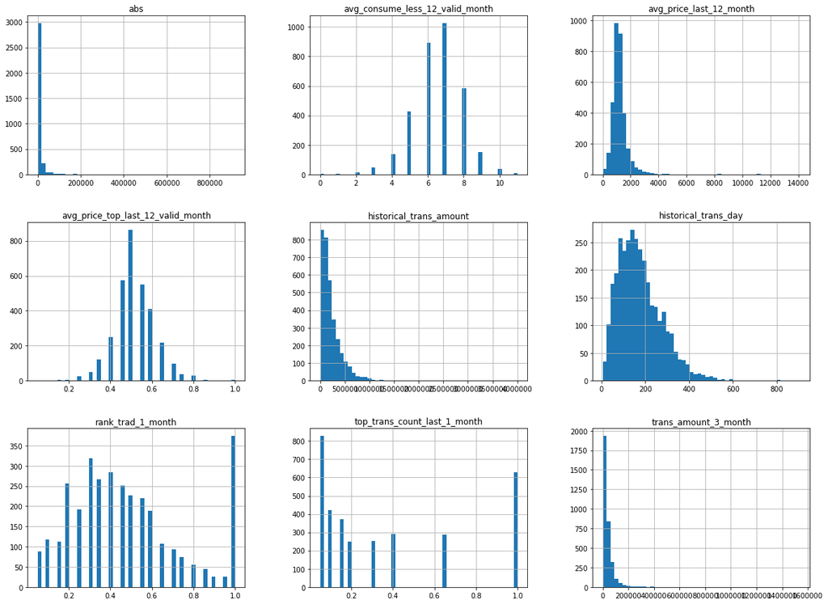

```python
obj = train_set[train_set.columns[i:j]]
obj.hist(bins=50, figsize = (20,15))
plt.show()
```

```python
obj.head(3).T
```

|  | 110 | 3394 | 3052 |
| --- | --- | --- | --- |
| historical_trans_amount | 181770.00 | 63350.00 | 97190.00 |
| historical_trans_day | 150.00 | 74.00 | 93.00 |
| rank_trad_1_month | 0.85 | 0.65 | 0.45 |
| trans_amount_3_month | 15610.00 | 12200.00 | 33280.00 |
| avg_consume_less_12_valid_month | 7.00 | 6.00 | 8.00 |
| abs | 2650.00 | 3460.00 | 1060.00 |
| top_trans_count_last_1_month | 1.00 | 0.40 | 0.30 |
| avg_price_last_12_month | 1220.00 | 630.00 | 930.00 |
| avg_price_top_last_12_valid_month | 0.45 | 0.65 | 0.55 |

#### null

```python
obj.isnull().sum()
```

```
historical_trans_amount               0
historical_trans_day                  0
rank_trad_1_month                     0
trans_amount_3_month                  0
avg_consume_less_12_valid_month       0
abs                                   0
top_trans_count_last_1_month          0
avg_price_last_12_month               0
avg_price_top_last_12_valid_month    76
dtype: int64
```

```python
cond = train_set['avg_price_top_last_12_valid_month'].isnull()
```

```python
train_set['avg_price_top_last_12_valid_month'].describe()
```

```
count    3249.000000
mean        0.516251
std         0.100640
min         0.050000
25%         0.450000
50%         0.500000
75%         0.550000
max         1.000000
Name: avg_price_top_last_12_valid_month, dtype: float64
```

```python
# 设置空值为0
train_set['avg_price_top_last_12_valid_month'] = train_set['avg_price_top_last_12_valid_month'].fillna(0)
```

```python
train_set[cond].T
```

|  | 2832 | 3904 | 1553 | 4228 | 4263 | 4233 | 38 | 502 | 3426 | 3545 | 3674 | 374 | 3732 | 13 | 2107 | 492 | 3137 | 293 | 1535 | 2960 | 1894 | 6 | 3350 | 3458 | 4729 | 1460 | 1205 | 3580 | 3921 | … |
| --- | --- | --- | --- | --- | --- | --- | --- | --- | --- | --- | --- | --- | --- | --- | --- | --- | --- | --- | --- | --- | --- | --- | --- | --- | --- | --- | --- | --- | --- | --- |
| custid | 3006621 | 543924 | 567458 | 1852931 | 2586262 | 18055 | 2889679 | 1654605 | 38830 | 709140 | 3227448 | 682720 | 1790276 | 193188 | 3851776 | 965994 | 1792026 | 305520 | 1135798 | 3056895 | 2279101 | 1205125 | 501776 | 1544306 | 1757011 | 1157868 | 470903 | 3725111 | 2287598 | … |
| trade_no | 20180507123503513000000388364593 | 20180507124244372000000388392557 | 20180507123302961000000388359240 | 20180507115719791000000388213054 | 20180507123224679000000388354996 | 20180504175838715000000381770864 | 20180507124907557000000023108427 | 20180507113204284000000388136467 | 20180504164736578000000381483045 | 20180507123406828000000023095461 | 20180507122733070000000388338286 | 20180507114754302000000388185855 | 20180507124507970000000388400044 | 20180507115807011000000388215609 | 20180507125120538000000023111852 | 20180507115902960000000388224560 | 20180504164146643000000381457832 | 20180507124427740000000388400426 | 20180507125127088000000388423619 | 20180507120510941000000023068917 | 20180507121832519000000388294850 | 20180507121931540000000388298915 | 20180507125226052000000388430338 | 20180507121007130000000388264907 | 20180507123942186000000388381507 | 20180504184149720000000381905931 | 20180507115623913000000388212094 | 20180507121620116000000023080504 | 20180507122533752000000388332222 | … |
| bank_card_no | 卡号1 | 卡号1 | 卡号1 | 卡号1 | 卡号1 | 卡号1 | 卡号1 | 卡号1 | 卡号1 | 卡号1 | 卡号1 | 卡号1 | 卡号1 | 卡号1 | 卡号1 | 卡号1 | 卡号1 | 卡号1 | 卡号1 | 卡号1 | 卡号1 | 卡号1 | 卡号1 | 卡号1 | 卡号1 | 卡号1 | 卡号1 | 卡号1 | 卡号1 | … |
| low_volume_percent | 0.01 | 0.05 | 0.02 | 0.01 | 0 | 0.01 | 0.04 | 0 | 0.01 | 0 | 0.12 | 0.02 | 0.02 | 0.01 | 0.05 | 0.11 | 0 | 0.01 | 0 | 0.01 | 0.05 | 0.02 | 0.01 | 0.04 | 0.17 | 0 | 0 | 0.01 | 0.03 | … |
| middle_volume_percent | 0.99 | 0.95 | 0.98 | 0.99 | 1 | 0.59 | 0.96 | 1 | 0.84 | 0.36 | 0.88 | 0.98 | 0.98 | 0.79 | 0.8 | 0.89 | 0 | 0.85 | 0.48 | 0.99 | 0.95 | 0.98 | 0.99 | 0.96 | 0.83 | 0.55 | 1 | 0.99 | 0.97 | … |
| take_amount_in_later_12_month_highest | 0 | 0 | 0 | 0 | 0 | 0 | 0 | 0 | 0 | 0 | 0 | 0 | 0 | 0 | 0 | 0 | 0 | 0 | 0 | 0 | 0 | 0 | 0 | 0 | 0 | 0 | 0 | 0 | 0 | … |
| trans_amount_increase_rate_lately | 1.82 | 0.89 | 1.61 | 0.67 | 1.76 | 1.03 | 0.27 | 1 | 7.82 | 0.19 | 2.02 | 0.81 | 1.03 | 1.24 | 0.47 | 2.03 | 0.4 | 0.99 | 0.71 | 1.93 | 0.91 | 23.67 | 1.29 | 47596.7 | 0.88 | 1.15 | 0.83 | 0.9 | 2.38 | … |
| trans_activity_month | 0.88 | 0.96 | 0.57 | 0.67 | 0.67 | 0.83 | 1 | 0.57 | 0.52 | 1 | 0.7 | 1 | 0.53 | 1 | 0.83 | 0.8 | 1 | 0.8 | 0.35 | 0.83 | 0.48 | 0.94 | 0.95 | 1 | 1 | 0.94 | 0.48 | 0.34 | 1 | … |
| trans_activity_day | 0.197 | 0.283 | 0.097 | 0.175 | 0.125 | 0.115 | 0.292 | 0.093 | 0.43 | 0.063 | 0.081 | 0.177 | 0.051 | 0.447 | 0.144 | 0.113 | 0.116 | 0.133 | 0.348 | 0.186 | 0.093 | 0.087 | 0.109 | 0.338 | 0.316 | 0.218 | 0.125 | 0.223 | 0.111 | … |
| transd_mcc | 14 | 16 | 10 | 10 | 10 | 11 | 12 | 11 | 21 | 9 | 8 | 15 | 8 | 16 | 10 | 12 | 3 | 11 | 10 | 14 | 10 | 10 | 11 | 14 | 16 | 13 | 6 | 14 | 15 | … |
| trans_days_interval_filter | 54 | 16 | 78 | 36 | 71 | 50 | 51 | 61 | 18 | 38 | 148 | 30 | 60 | 19 | 30 | 58 | 9999 | 33 | 33 | 26 | 29 | 54 | 83 | 48 | 42 | 56 | 97 | 45 | 35 | … |
| trans_days_interval | 35 | 20 | 35 | 40 | 25 | 53 | 15 | 51 | 15 | 37 | 112 | 17 | 30 | 13 | 29 | 22 | 15 | 117 | 11 | 24 | 29 | 53 | 58 | 23 | 27 | 59 | 31 | 41 | 31 | … |
| regional_mobility | 2 | 3 | 2 | 3 | 1 | 3 | 2 | 3 | 4 | 3 | 1 | 3 | 3 | 1 | 2 | 2 | 1 | 2 | 2 | 3 | 1 | 2 | 2 | 1 | 2 | 2 | 3 | 3 | 3 | … |
| student_feature | 0 | 0 | 0 | 0 | 0 | 0 | 0 | 0 | 0 | 0 | 0 | 0 | 0 | 0 | 0 | 0 | 0 | 0 | 0 | 0 | 0 | 0 | 0 | 0 | 0 | 0 | 0 | 0 | 0 | … |
| repayment_capability | 12780 | 13640 | 10130 | 16170 | 11290 | 7140 | 7470 | 11830 | 15550 | 13670 | 11470 | 12340 | 12360 | 31010 | 9700 | 11760 | 9190 | 11930 | 229670 | 14180 | 12050 | 11220 | 9170 | 12210 | 14100 | 16550 | 7850 | 10470 | 12690 | … |
| is_high_user | 0 | 0 | 0 | 0 | 0 | 0 | 0 | 0 | 0 | 0 | 0 | 0 | 0 | 0 | 0 | 0 | 1 | 0 | 0 | 0 | 0 | 0 | 0 | 0 | 0 | 0 | 1 | 0 | 0 | … |
| number_of_trans_from_2011 | 15 | 23 | 25 | 39 | 14 | 30 | 9 | 17 | 33 | 16 | 7 | 18 | 19 | 31 | 20 | 16 | 2 | 8 | 13 | 44 | 21 | 15 | 19 | 14 | 21 | 30 | 25 | 14 | 9 | … |
| first_transaction_time | 20161009 | 20160319 | 20140717 | 20130511 | 20160428 | 20150306 | 20170619 | 20150924 | 20121120 | 20161113 | 20170321 | 20160925 | 20141219 | 20150807 | 20160311 | 20160730 | 20180114 | 20170501 | 20141201 | 20131027 | 20140617 | 20161112 | 20160709 | 20170106 | 20160607 | 20150708 | 20130810 | 20141020 | 20170617 | … |
| historical_trans_amount | 64870 | 187550 | 24800 | 90700 | 20830 | 135270 | 24580 | 31930 | 243430 | 36460 | 6680 | 60440 | 32260 | 336460 | 42160 | 14800 | 0 | 35110 | 39560 | 59060 | 17170 | 34140 | 59520 | 148260 | 71860 | 76220 | 11990 | 48180 | 23950 | … |
| historical_trans_day | 71 | 191 | 65 | 104 | 36 | 120 | 79 | 37 | 243 | 28 | 17 | 88 | 28 | 302 | 79 | 55 | 7 | 32 | 100 | 134 | 55 | 50 | 66 | 134 | 163 | 137 | 67 | 76 | 30 | … |
| rank_trad_1_month | 0.6 | 0.6 | 0.55 | 0.5 | 1 | 0.55 | 0.4 | 1 | 0.45 | 0.2 | 1 | 0.9 | 1 | 0.7 | 0.65 | 0.85 | 1 | 0.35 | 1 | 0.45 | 1 | 1 | 0.9 | 0.95 | 0.8 | 0.7 | 1 | 1 | 0.4 | … |
| trans_amount_3_month | 16350 | 10480 | 5840 | 11620 | 5440 | 3400 | 15710 | 3750 | 48130 | 13430 | 2840 | 5310 | 0 | 47010 | 5450 | 2770 | 0 | 16430 | 4260 | 11070 | 1540 | 3080 | 1340 | 16120 | 7200 | 1650 | 0 | 12080 | 10940 | … |
| avg_consume_less_12_valid_month | 7 | 6 | 8 | 8 | 3 | 6 | 6 | 6 | 6 | 10 | 3 | 5 | 5 | 7 | 6 | 6 | 0 | 4 | 8 | 7 | 8 | 6 | 5 | 7 | 7 | 5 | 4 | 7 | 4 | … |
| abs | 260 | 1550 | 120 | 2380 | 3390 | 1180 | 5890 | 530 | 4160 | 250 | 830 | 390 | 1120 | 560 | 730 | 1020 | 0 | 380 | 56230 | 650 | 1010 | 110 | 1070 | 2680 | 1050 | 1760 | 6270 | 7810 | 1000 | … |
| top_trans_count_last_1_month | 0.65 | 0.3 | 0.65 | 1 | 1 | 1 | 0.4 | 1 | 0.2 | 0.4 | 1 | 1 | 1 | 0.15 | 0.4 | 1 | 1 | 1 | 1 | 0.2 | 1 | 1 | 0.65 | 1 | 1 | 0.4 | 1 | 1 | 0.15 | … |
| avg_price_last_12_month | 1200 | 1170 | 930 | 1230 | 1500 | 1270 | 940 | 1490 | 1430 | 1330 | 410 | 900 | 1740 | 1360 | 630 | 440 | 0 | 1400 | 2790 | 700 | 720 | 1250 | 1570 | 830 | 350 | 1240 | 1290 | 1150 | 770 | … |
| avg_price_top_last_12_valid_month | 0 | 0 | 0 | 0 | 0 | 0 | 0 | 0 | 0 | 0 | 0 | 0 | 0 | 0 | 0 | 0 | 0 | 0 | 0 | 0 | 0 | 0 | 0 | 0 | 0 | 0 | 0 | 0 | 0 | … |
| reg_preference_for_trad | 一线城市 | 一线城市 | 一线城市 | 三线城市 | 三线城市 | 一线城市 | 三线城市 | 一线城市 | 一线城市 | 一线城市 | 三线城市 | 一线城市 | 一线城市 | 一线城市 | 一线城市 | 三线城市 | 境外 | 一线城市 | 三线城市 | 一线城市 | 三线城市 | 一线城市 | 一线城市 | 一线城市 | 一线城市 | 三线城市 | 一线城市 | 一线城市 | 一线城市 | … |
| trans_top_time_last_1_month | 19 | 8 | 8 | 0 | 0 | 0 | 14 | 0 | 14 | 11 | 0 | 0 | 0 | 19 | 12 | 0 | NaN | 0 | 0 | 17 | 0 | 0 | 0 | 0 | 0 | 5 | 0 | 0 | 6 | … |
| trans_top_time_last_6_month | 32 | 16 | 31 | 36 | 41 | 50 | 22 | 21 | 18 | 30 | 30 | 30 | 19 | 19 | 29 | 58 | NaN | 33 | 33 | 26 | 29 | 54 | 83 | 48 | 42 | 56 | 0 | 23 | 27 | … |

[output cut: 59 more lines]

## part4 27:36 列

```python
i,j = 27,36
train_set.columns[i:j]
```

```
Index(['reg_preference_for_trad', 'trans_top_time_last_1_month',
       'trans_top_time_last_6_month', 'consume_top_time_last_1_month',
       'consume_top_time_last_6_month', 'cross_consume_count_last_1_month',
       'trans_fail_top_count_enum_last_1_month',
       'trans_fail_top_count_enum_last_6_month',
       'trans_fail_top_count_enum_last_12_month'],
      dtype='object')
```

#### fig

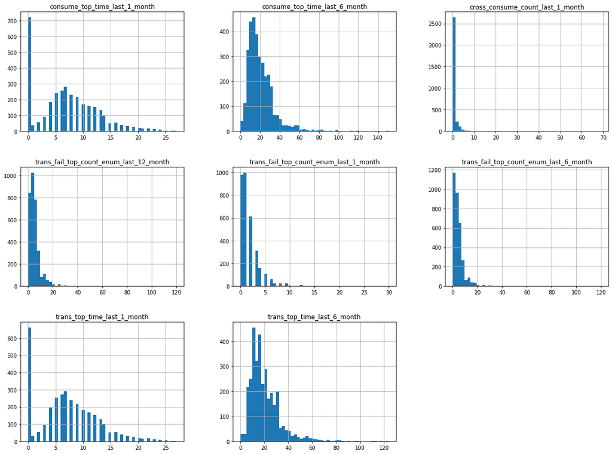

```python
obj = train_set[train_set.columns[i:j]]
obj.hist(bins=50, figsize = (20,15))
plt.show()
```

```python
obj.head(3).T
```

|  | 110 | 3394 | 3052 |
| --- | --- | --- | --- |
| reg_preference_for_trad | 一线城市 | 一线城市 | 一线城市 |
| trans_top_time_last_1_month | 0 | 14 | 11 |
| trans_top_time_last_6_month | 29 | 17 | 21 |
| consume_top_time_last_1_month | 0 | 14 | 11 |
| consume_top_time_last_6_month | 29 | 17 | 21 |
| cross_consume_count_last_1_month | 0 | 1 | 0 |
| trans_fail_top_count_enum_last_1_month | 6 | 1 | 0 |
| trans_fail_top_count_enum_last_6_month | 9 | 4 | 4 |
| trans_fail_top_count_enum_last_12_month | 9 | 9 | 21 |

#### null

```python
obj.isnull().sum()
```

```
reg_preference_for_trad                      0
trans_top_time_last_1_month                  4
trans_top_time_last_6_month                  4
consume_top_time_last_1_month                4
consume_top_time_last_6_month                4
cross_consume_count_last_1_month           288
trans_fail_top_count_enum_last_1_month      11
trans_fail_top_count_enum_last_6_month      11
trans_fail_top_count_enum_last_12_month     11
dtype: int64
```

### 【分类】reg_preference_for_trad

```python
train_set['reg_preference_for_trad'].value_counts()
```

```
一线城市    2380
三线城市     747
境外       103
二线城市      92
其他城市       3
Name: reg_preference_for_trad, dtype: int64
```

### trans_top_time_last_1_month 空值处理

```python
cond = train_set['trans_top_time_last_1_month'].isnull()
train_set[cond]
```

|  | custid | trade_no | bank_card_no | low_volume_percent | middle_volume_percent | take_amount_in_later_12_month_highest | trans_amount_increase_rate_lately | trans_activity_month | trans_activity_day | transd_mcc | trans_days_interval_filter | trans_days_interval | regional_mobility | student_feature | repayment_capability | is_high_user | number_of_trans_from_2011 | first_transaction_time | historical_trans_amount | historical_trans_day | rank_trad_1_month | trans_amount_3_month | avg_consume_less_12_valid_month | abs | top_trans_count_last_1_month | avg_price_last_12_month | avg_price_top_last_12_valid_month | reg_preference_for_trad | trans_top_time_last_1_month | … |
| --- | --- | --- | --- | --- | --- | --- | --- | --- | --- | --- | --- | --- | --- | --- | --- | --- | --- | --- | --- | --- | --- | --- | --- | --- | --- | --- | --- | --- | --- | --- |
| 3137 | 1792026 | 20180504164146643000000381457832 | 卡号1 | 0.0 | 0.0 | 0 | 0.40 | 1.00 | 0.116 | 3.0 | 9999.0 | 15.0 | 1.0 | 0.0 | 9190 | 1 | 2.0 | 20180114 | 0 | 7.0 | 1.0 | 0 | 0.0 | 0 | 1.0 | 0 | 0.0 | 境外 | NaN | … |
| 1587 | 3318145 | 20180507123624755000000388373165 | 卡号1 | 0.0 | 0.0 | 0 | 0.78 | 1.00 | 0.116 | 2.0 | 9999.0 | 173.0 | 1.0 | 0.0 | 10750 | 0 | 2.0 | 20160409 | 0 | 7.0 | 1.0 | 0 | 0.0 | 0 | 1.0 | 0 | 0.0 | 一线城市 | NaN | … |
| 3623 | 2839384 | 20180507115704600000000388214794 | 卡号1 | 0.0 | 0.0 | 0 | 0.11 | 0.79 | 0.192 | 8.0 | 9999.0 | 67.0 | 1.0 | 0.0 | 840 | 0 | 11.0 | 20170113 | 0 | 57.0 | 1.0 | 0 | 0.0 | 14730 | 1.0 | 0 | 1.0 | 境外 | NaN | … |
| 2237 | 1240369 | 20180507121258919000000388272886 | 卡号1 | 0.0 | 0.0 | 0 | 0.74 | 0.87 | 0.110 | 4.0 | 9999.0 | 65.0 | 1.0 | 0.0 | 4920 | 0 | 13.0 | 20161126 | 150 | 41.0 | 1.0 | 0 | 0.0 | 9200 | 1.0 | 0 | 0.0 | 境外 | NaN | … |

```python
z = train_set[cond].isnull().sum()
z[z > 0]
```

```
trans_top_time_last_1_month            4
trans_top_time_last_6_month            4
consume_top_time_last_1_month          4
consume_top_time_last_6_month          4
cross_consume_count_last_1_month       4
consume_mini_time_last_1_month         4
max_consume_count_later_6_month        4
railway_consume_count_last_12_month    4
jewelry_consume_count_last_6_month     4
dtype: int64
```

```python
index = z[z > 0].index
index
```

```
Index(['trans_top_time_last_1_month', 'trans_top_time_last_6_month',
       'consume_top_time_last_1_month', 'consume_top_time_last_6_month',
       'cross_consume_count_last_1_month', 'consume_mini_time_last_1_month',
       'max_consume_count_later_6_month',
       'railway_consume_count_last_12_month',
       'jewelry_consume_count_last_6_month'],
      dtype='object')
```

```python
# 空值处理
cond = train_set['trans_top_time_last_1_month'].isnull()
train_set.loc[cond, index] = 0
```

```python
# trans_top_time_last_1_month                  4
# trans_top_time_last_6_month                  4
# consume_top_time_last_1_month                4
# consume_top_time_last_6_month                4
# cross_consume_count_last_1_month           288
# trans_fail_top_count_enum_last_1_month      11
# trans_fail_top_count_enum_last_6_month      11
# trans_fail_top_count_enum_last_12_month     11
```

```python
for col in ['trans_top_time_last_1_month', 'trans_top_time_last_6_month',
       'consume_top_time_last_1_month', 'consume_top_time_last_6_month',
       'cross_consume_count_last_1_month', 'consume_mini_time_last_1_month',
       'max_consume_count_later_6_month',
       'railway_consume_count_last_12_month',
       'jewelry_consume_count_last_6_month',
            'trans_fail_top_count_enum_last_1_month',
           'trans_fail_top_count_enum_last_6_month',
           'trans_fail_top_count_enum_last_12_month']:
    train_set[col] = train_set[col].fillna(0)
```

```python
obj = train_set[train_set.columns[i:j]]
```

```python
obj.isnull().sum()
```

```
reg_preference_for_trad                    0
trans_top_time_last_1_month                0
trans_top_time_last_6_month                0
consume_top_time_last_1_month              0
consume_top_time_last_6_month              0
cross_consume_count_last_1_month           0
trans_fail_top_count_enum_last_1_month     0
trans_fail_top_count_enum_last_6_month     0
trans_fail_top_count_enum_last_12_month    0
dtype: int64
```

```python
train_set['cross_consume_count_last_1_month'].isnull().sum()
```

```
0
```

```python
train_set['trans_fail_top_count_enum_last_12_month'].describe()
```

```
count    3325.000000
mean        5.283609
std         5.029503
min         0.000000
25%         2.000000
50%         4.000000
75%         6.000000
max       120.000000
Name: trans_fail_top_count_enum_last_12_month, dtype: float64
```

```python
train_set['cross_consume_count_last_1_month'].describe()
```

```
count    3325.000000
mean        0.572632
std         2.084822
min         0.000000
25%         0.000000
50%         0.000000
75%         1.000000
max        69.000000
Name: cross_consume_count_last_1_month, dtype: float64
```

## part5 36:45 列

```python
i,j =  36,45
train_set.columns[i:j]
```

```
Index(['consume_mini_time_last_1_month',
       'max_cumulative_consume_later_1_month',
       'max_consume_count_later_6_month',
       'railway_consume_count_last_12_month',
       'pawns_auctions_trusts_consume_last_1_month',
       'pawns_auctions_trusts_consume_last_6_month',
       'jewelry_consume_count_last_6_month', 'source',
       'first_transaction_day'],
      dtype='object')
```

#### fig

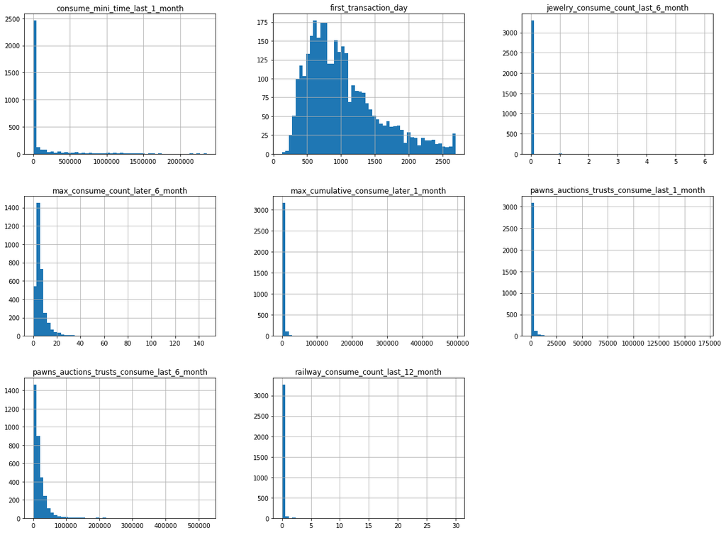

```python
obj = train_set[train_set.columns[i:j]]
obj.hist(bins=50, figsize = (20,15))
plt.show()
```

```python
obj.head(3).T
```

|  | 110 | 3394 | 3052 |
| --- | --- | --- | --- |
| consume_mini_time_last_1_month | 0 | 0 | 0 |
| max_cumulative_consume_later_1_month | 220 | 470 | 1950 |
| max_consume_count_later_6_month | 6 | 4 | 12 |
| railway_consume_count_last_12_month | 0 | 0 | 0 |
| pawns_auctions_trusts_consume_last_1_month | 0 | 470 | 1950 |
| pawns_auctions_trusts_consume_last_6_month | 10160 | 2060 | 8240 |
| jewelry_consume_count_last_6_month | 0 | 0 | 0 |
| source | xs | xs | xs |
| first_transaction_day | 458 | 416 | 1288 |

#### null

```python
obj.isnull().sum()
```

```
consume_mini_time_last_1_month                0
max_cumulative_consume_later_1_month          0
max_consume_count_later_6_month               0
railway_consume_count_last_12_month           0
pawns_auctions_trusts_consume_last_1_month    0
pawns_auctions_trusts_consume_last_6_month    0
jewelry_consume_count_last_6_month            0
source                                        0
first_transaction_day                         0
dtype: int64
```

### 【可删除】source

```python
train_set['source'].value_counts()
```

```
xs    3325
Name: source, dtype: int64
```

## part6 45:54 列

```python
i,j = 45,54
train_set.columns[i:j]
```

```
Index(['trans_day_last_12_month', 'id_name', 'apply_score',
       'apply_credibility', 'query_org_count', 'query_finance_count',
       'query_cash_count', 'query_sum_count', 'latest_query_time'],
      dtype='object')
```

#### fig

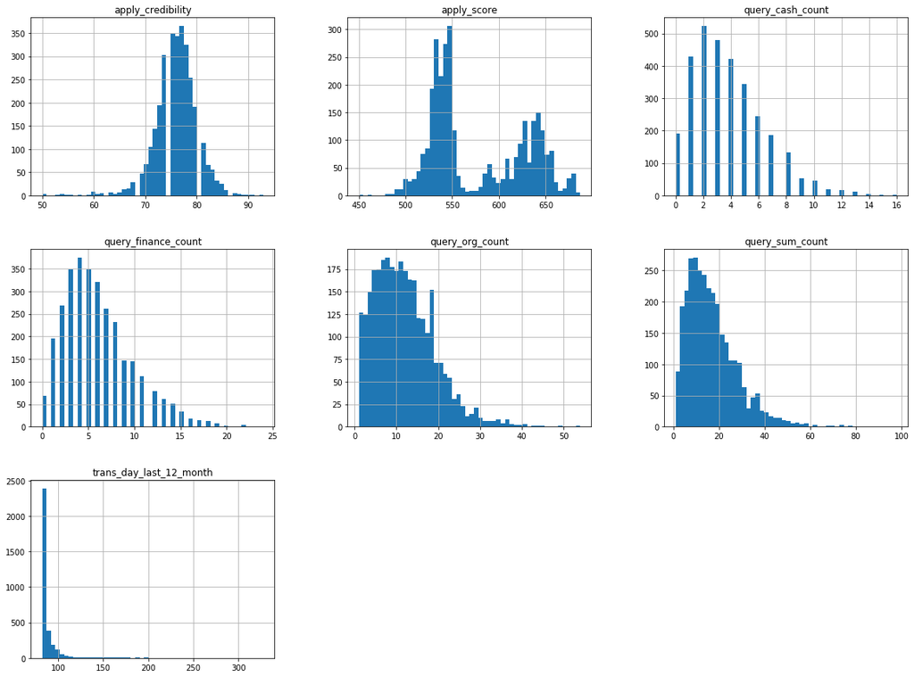

```python
obj = train_set[train_set.columns[i:j]]
obj.hist(bins=50, figsize = (20,15))
plt.show()
```

```python
obj.head(3).T
```

|  | 110 | 3394 | 3052 |
| --- | --- | --- | --- |
| trans_day_last_12_month | 99 | 82 | 82 |
| id_name | 杨涛 | 詹振华 | 张宽宽 |
| apply_score | 535 | 540 | 516 |
| apply_credibility | 73 | 81 | 75 |
| query_org_count | 16 | 8 | 14 |
| query_finance_count | 6 | 3 | 8 |
| query_cash_count | 7 | 3 | 6 |
| query_sum_count | 24 | 9 | 19 |
| latest_query_time | 2018-05-04 | 2018-04-07 | 2018-05-04 |

#### null

```python
obj.isnull().sum()
```

```
trans_day_last_12_month      0
id_name                    202
apply_score                220
apply_credibility          220
query_org_count            220
query_finance_count        220
query_cash_count           220
query_sum_count            220
latest_query_time          220
dtype: int64
```

### 【可删除】id_name

```python
train_set['id_name'].value_counts().head()
```

```
陈鹏    4
张龙    4
王剑    3
李杰    3
李明    3
Name: id_name, dtype: int64
```

```python
train_set.head().T
```

|  | 110 | 3394 | 3052 | 490 | 1 |
| --- | --- | --- | --- | --- | --- |
| custid | 3302657 | 2733732 | 2851871 | 63272 | 534047 |
| trade_no | 20180504182022079000000381847944 | 20180507115234629000000023058189 | 20180507121124018000000388268874 | 20180507123321187000000023093621 | 20180507121002192000000023073000 |
| bank_card_no | 卡号1 | 卡号1 | 卡号1 | 卡号1 | 卡号1 |
| low_volume_percent | 0.01 | 0.03 | 0.02 | 0.02 | 0.02 |
| middle_volume_percent | 0.99 | 0.97 | 0.86 | 0.81 | 0.94 |
| take_amount_in_later_12_month_highest | 4000 | 500 | 0 | 1000 | 2000 |
| trans_amount_increase_rate_lately | 0.96 | 0.87 | 1.98 | 1.49 | 1.28 |
| trans_activity_month | 1 | 1 | 0.7 | 0.73 | 1 |
| trans_activity_day | 0.405 | 0.205 | 0.205 | 0.555 | 0.458 |
| transd_mcc | 16 | 18 | 18 | 23 | 19 |
| trans_days_interval_filter | 29 | 27 | 53 | 15 | 30 |
| trans_days_interval | 28 | 27 | 33 | 8 | 14 |
| regional_mobility | 1 | 3 | 2 | 4 | 4 |
| student_feature | 1 | 0 | 0 | 1 | 1 |
| repayment_capability | 17570 | 15310 | 12240 | 4320 | 16970 |
| is_high_user | 0 | 0 | 0 | 0 | 0 |
| number_of_trans_from_2011 | 13 | 12 | 28 | 40 | 23 |
| first_transaction_time | 20170217 | 20170331 | 20141110 | 20130817 | 20160402 |
| historical_trans_amount | 181770 | 63350 | 97190 | 373700 | 302910 |
| historical_trans_day | 150 | 74 | 93 | 356 | 224 |
| rank_trad_1_month | 0.85 | 0.65 | 0.45 | 0.3 | 0.35 |
| trans_amount_3_month | 15610 | 12200 | 33280 | 61940 | 10590 |
| avg_consume_less_12_valid_month | 7 | 6 | 8 | 8 | 5 |
| abs | 2650 | 3460 | 1060 | 26200 | 6950 |
| top_trans_count_last_1_month | 1 | 0.4 | 0.3 | 0.1 | 0.05 |
| avg_price_last_12_month | 1220 | 630 | 930 | 1390 | 1210 |
| avg_price_top_last_12_valid_month | 0.45 | 0.65 | 0.55 | 0.45 | 0.5 |
| reg_preference_for_trad | 一线城市 | 一线城市 | 一线城市 | 三线城市 | 一线城市 |
| trans_top_time_last_1_month | 0 | 14 | 11 | 15 | 13 |
| trans_top_time_last_6_month | 29 | 17 | 21 | 15 | 30 |

[output cut: 59 more lines]

1. 数值型取中位数
2. 日期取众数

```python
train_set.columns[45:]
```

```
Index(['trans_day_last_12_month', 'id_name', 'apply_score',
       'apply_credibility', 'query_org_count', 'query_finance_count',
       'query_cash_count', 'query_sum_count', 'latest_query_time',
       'latest_one_month_apply', 'latest_three_month_apply',
       'latest_six_month_apply', 'loans_score', 'loans_credibility_behavior',
       'loans_count', 'loans_settle_count', 'loans_overdue_count',
       'loans_org_count_behavior', 'consfin_org_count_behavior',
       'loans_cash_count', 'latest_one_month_loan', 'latest_three_month_loan',
       'latest_six_month_loan', 'history_suc_fee', 'history_fail_fee',
       'latest_one_month_suc', 'latest_one_month_fail', 'loans_long_time',
       'loans_latest_time', 'loans_credit_limit', 'loans_credibility_limit',
       'loans_org_count_current', 'loans_product_count', 'loans_max_limit',
       'loans_avg_limit', 'consfin_credit_limit', 'consfin_credibility',
       'consfin_org_count_current', 'consfin_product_count',
       'consfin_max_limit', 'consfin_avg_limit', 'latest_query_day',
       'loans_latest_day', 'status'],
      dtype='object')
```

```python
for col in ['trans_day_last_12_month', 'id_name', 'apply_score',
       'apply_credibility', 'query_org_count', 'query_finance_count',
       'query_cash_count', 'query_sum_count', 'latest_query_time',
       'latest_one_month_apply', 'latest_three_month_apply',
       'latest_six_month_apply', 'loans_score', 'loans_credibility_behavior',
       'loans_count', 'loans_settle_count', 'loans_overdue_count',
       'loans_org_count_behavior', 'consfin_org_count_behavior',
       'loans_cash_count', 'latest_one_month_loan', 'latest_three_month_loan',
       'latest_six_month_loan', 'history_suc_fee', 'history_fail_fee',
       'latest_one_month_suc', 'latest_one_month_fail', 'loans_long_time',
       'loans_latest_time', 'loans_credit_limit', 'loans_credibility_limit',
       'loans_org_count_current', 'loans_product_count', 'loans_max_limit',
       'loans_avg_limit', 'consfin_credit_limit', 'consfin_credibility',
       'consfin_org_count_current', 'consfin_product_count',
       'consfin_max_limit', 'consfin_avg_limit', 'latest_query_day',
       'loans_latest_day',]:
    if col in ['id_name', 'latest_query_time', 'loans_latest_time']:
        train_set[col] = train_set[col].fillna(train_set[col].dropna().mode().iloc[0])
    else:
        train_set[col] = train_set[col].fillna(train_set[col].median())
```

```python
train_set.isnull().sum()
```

```
custid                                        0
trade_no                                      0
bank_card_no                                  0
low_volume_percent                            0
middle_volume_percent                         0
take_amount_in_later_12_month_highest         0
trans_amount_increase_rate_lately             0
trans_activity_month                          0
trans_activity_day                            0
transd_mcc                                    0
trans_days_interval_filter                    0
trans_days_interval                           0
regional_mobility                             0
student_feature                               0
repayment_capability                          0
is_high_user                                  0
number_of_trans_from_2011                     0
first_transaction_time                        0
historical_trans_amount                       0
historical_trans_day                          0
rank_trad_1_month                             0
trans_amount_3_month                          0
avg_consume_less_12_valid_month               0
abs                                           0
top_trans_count_last_1_month                  0
avg_price_last_12_month                       0
avg_price_top_last_12_valid_month             0
reg_preference_for_trad                       0
trans_top_time_last_1_month                   0
trans_top_time_last_6_month                   0
consume_top_time_last_1_month                 0
consume_top_time_last_6_month                 0
cross_consume_count_last_1_month              0
trans_fail_top_count_enum_last_1_month        0
trans_fail_top_count_enum_last_6_month        0
trans_fail_top_count_enum_last_12_month       0
consume_mini_time_last_1_month                0
max_cumulative_consume_later_1_month          0
max_consume_count_later_6_month               0
railway_consume_count_last_12_month           0
```

[output cut: 35 more lines]

```
loans_credibility_limit                       0
loans_org_count_current                       0
loans_product_count                           0
loans_max_limit                               0
loans_avg_limit                               0
consfin_credit_limit                          0
consfin_credibility                           0
consfin_org_count_current                     0
consfin_product_count                         0
consfin_max_limit                             0
consfin_avg_limit                             0
latest_query_day                              0
loans_latest_day                              0
status                                        0
dtype: int64
```

# 图形

```python
train_set.columns[:10]
```

```
Index(['custid', 'trade_no', 'bank_card_no', 'low_volume_percent',
       'middle_volume_percent', 'take_amount_in_later_12_month_highest',
       'trans_amount_increase_rate_lately', 'trans_activity_month',
       'trans_activity_day', 'transd_mcc'],
      dtype='object')
```

```python
col = 'low_volume_percent'
```

```python
# fig, axes = plt.subplots(1, 2, sharey=True)
# for i in range(2):
#     for j in range(2):
#         axes[i, j].hist(randn(500), bins=50, color = 'k', alpha = 0.5)
# plt.subplots_adjust(wspace = 0, hspace = 0)
```

```python
cond = train_set.status == 1
```

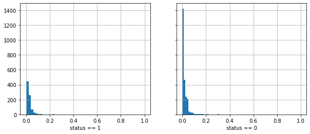

```python
fig, axes = plt.subplots(1, 2, sharex=True, sharey=True, figsize = (10,4))
ax1, ax2 = axes
train_set.loc[cond, col].hist(bins=50, ax = ax1)
ax1.set_xlabel('status == 1')
train_set.loc[~cond,col].hist(bins=50, ax = ax2)
ax2.set_xlabel('status == 0')
# plt.subplots_adjust(wspace = 0, hspace = 0)
plt.show()
```

## 同轴展示

```
low_volume_percent
```

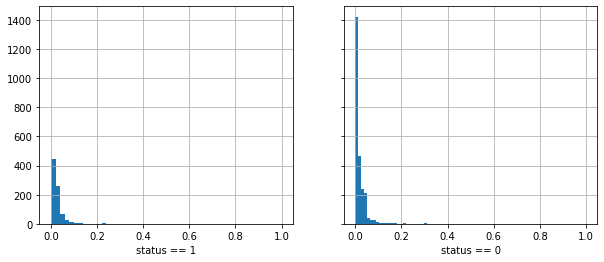

```
middle_volume_percent
```

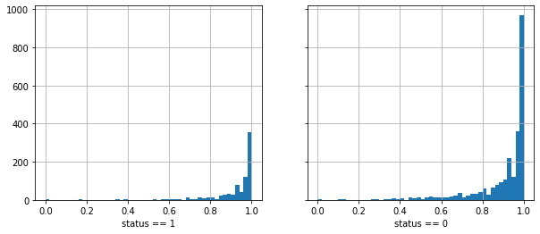

```
take_amount_in_later_12_month_highest
```

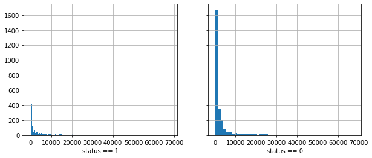

```
trans_amount_increase_rate_lately
```

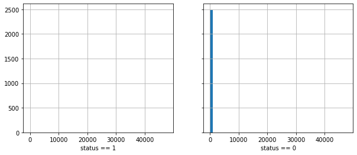

```
trans_activity_month
```

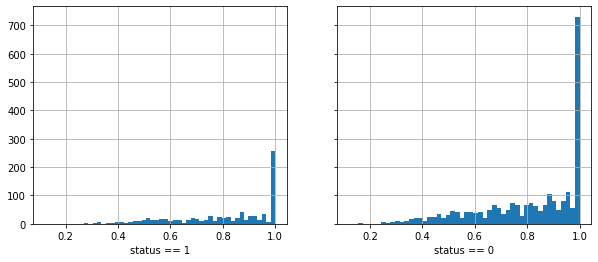

```
trans_activity_day
```

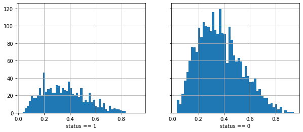

```
transd_mcc
```

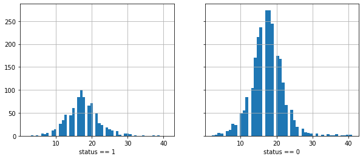

```
trans_days_interval_filter
```

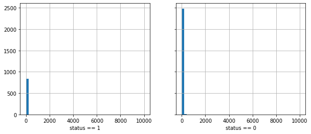

```
trans_days_interval
```

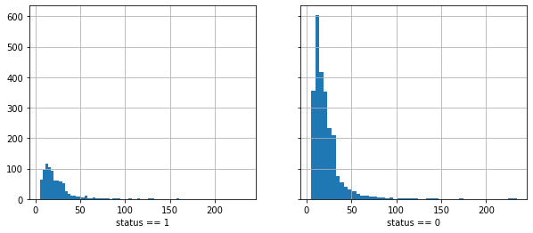

```
regional_mobility
```

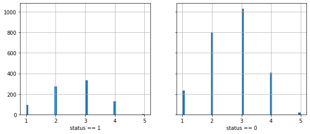

```
student_feature
```

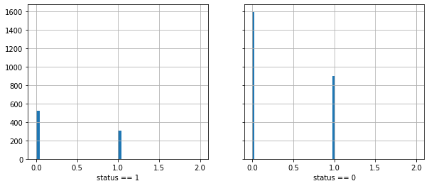

```
repayment_capability
```

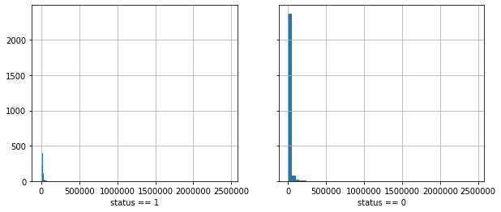

```
is_high_user
```

[68 more figures not shown]

```python
for col in train_set.columns:
    if col in ['custid', 'trade_no', 'bank_card_no']:
        continue
    if train_set[col].dtype == 'object': continue

    try:
        print(col)

        fig, axes = plt.subplots(1, 2, sharex=True, sharey=True, figsize = (10,4))
        ax1, ax2 = axes
        train_set.loc[cond, col].hist(bins=50, ax = ax1)
        ax1.set_xlabel('status == 1')
        train_set.loc[~cond,col].hist(bins=50, ax = ax2)
        ax2.set_xlabel('status == 0')
        # plt.subplots_adjust(wspace = 0, hspace = 0)
        plt.show()

        print()
    except Exception as e:
        print(e)

    # break
```

## 不同轴

```
low_volume_percent
```

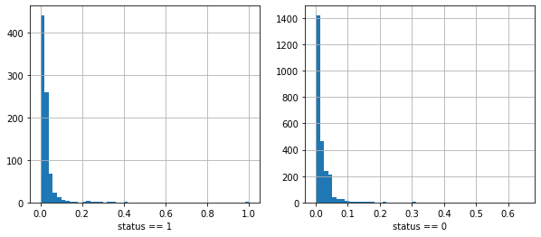

```
middle_volume_percent
```

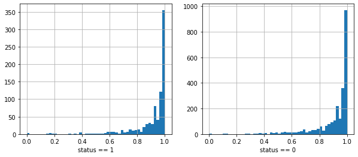

```
take_amount_in_later_12_month_highest
```

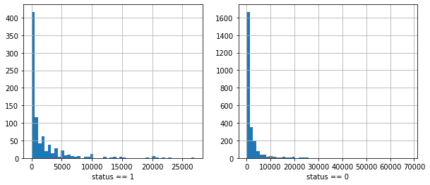

```
trans_amount_increase_rate_lately
```

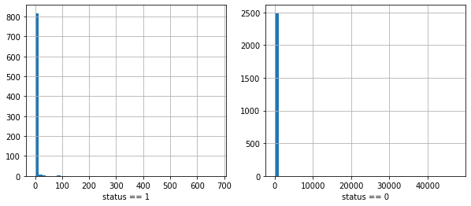

```
trans_activity_month
```

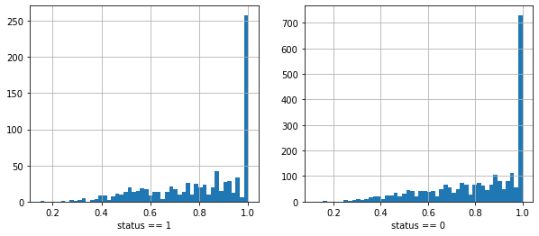

```
trans_activity_day
```

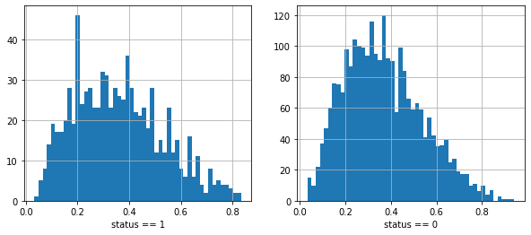

```
transd_mcc
```

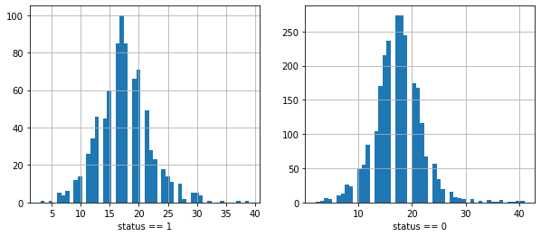

```
trans_days_interval_filter
```

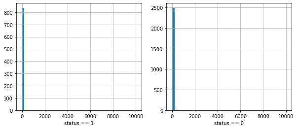

```
trans_days_interval
```

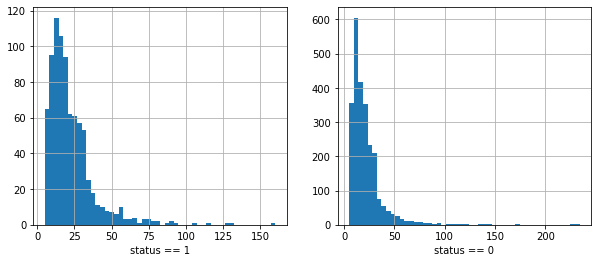

```
regional_mobility
```

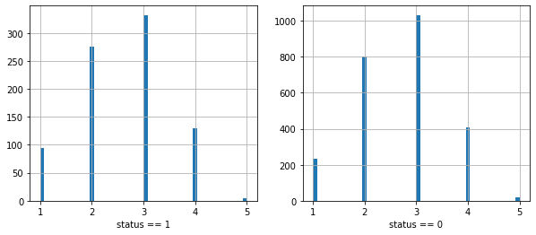

```
student_feature
```

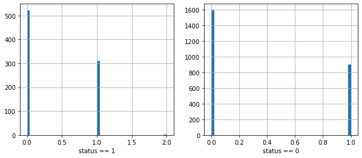

```
repayment_capability
```

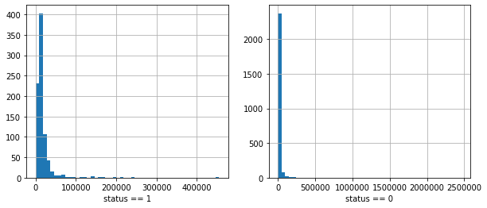

```
is_high_user
```

[68 more figures not shown]

```python
for col in train_set.columns:
    if col in ['custid', 'trade_no', 'bank_card_no']:
        continue
    if isinstance(train_set[col].iloc[0], str): continue
    try:
        print(col)
        fig = plt.figure(figsize = (10,4))
        ax1 = fig.add_subplot(121)
        ax2 = fig.add_subplot(122)

        train_set.loc[cond, col].hist(bins=50, ax = ax1)
        ax1.set_xlabel('status == 1')
        train_set.loc[~cond,col].hist(bins=50, ax = ax2)
        ax2.set_xlabel('status == 0')
        plt.show()

        print()
    except Exception as e:
        print(e)
```